# Airline Statistics and Cancellations Causes

## by Ghaida S. Altuwaijri

### 11-Aug-2020

## Preliminary Wrangling

The data consists of flight arrival and departure details for all commercial flights within the USA, from October 1987 to April 2008. This is a large dataset: there are nearly 120 million records in total, and takes up 1.6 gigabytes of space compressed and 12 gigabytes when uncompressed. To make sure not overwhelmed by the size of the data.

```python
# import all packages and set plots to be embedded inline
import numpy as np
import pandas as pd
import matplotlib.pyplot as plt
import seaborn as sb
%matplotlib inline
```

```
- A flight is considered delayed when it arrived 15 or more minutes than the schedule (see definitions in Frequently Asked Questions). Delayed minutes are calculated for delayed flights only.
- When multiple causes are assigned to one delayed flight, each cause is prorated based on delayed minutes it is responsible for. The displayed numbers are rounded and may not add up to the total.
```

```python
# load in the dataset into a pandas dataframe
df = pd.read_csv('2008.csv')
df2 = pd.read_csv('carriers.csv')
```

```python
# high-level overview of data shape and composition
df.info()
df.sample(10)
```

```
<class 'pandas.core.frame.DataFrame'>
RangeIndex: 2389217 entries, 0 to 2389216
Data columns (total 29 columns):
 #   Column             Dtype
---  ------             -----
 0   Year               int64
 1   Month              int64
 2   DayofMonth         int64
 3   DayOfWeek          int64
 4   DepTime            float64
 5   CRSDepTime         int64
 6   ArrTime            float64
 7   CRSArrTime         int64
 8   UniqueCarrier      object
 9   FlightNum          int64
```

[output cut: 21 more lines]

|  | Year | Month | DayofMonth | DayOfWeek | DepTime | CRSDepTime | ArrTime | CRSArrTime | UniqueCarrier | FlightNum | ... | TaxiIn | TaxiOut | Cancelled | CancellationCode | Diverted | CarrierDelay | WeatherDelay | NASDelay | SecurityDelay | LateAircraftDelay |
| --- | --- | --- | --- | --- | --- | --- | --- | --- | --- | --- | --- | --- | --- | --- | --- | --- | --- | --- | --- | --- | --- |
| 1373013 | 2008 | 3 | 18 | 2 | 2124.0 | 2125 | 2241.0 | 2229 | OO | 3790 | ... | 3.0 | 24.0 | 0 | NaN | 0 | NaN | NaN | NaN | NaN | NaN |
| 1602168 | 2008 | 3 | 4 | 2 | 701.0 | 705 | 846.0 | 859 | MQ | 4892 | ... | 7.0 | 14.0 | 0 | NaN | 0 | NaN | NaN | NaN | NaN | NaN |
| 1415400 | 2008 | 3 | 6 | 4 | 856.0 | 900 | 1134.0 | 1145 | UA | 606 | ... | 2.0 | 17.0 | 0 | NaN | 0 | NaN | NaN | NaN | NaN | NaN |
| 1903360 | 2008 | 4 | 18 | 5 | 1436.0 | 1435 | 1617.0 | 1627 | XE | 2167 | ... | 6.0 | 16.0 | 0 | NaN | 0 | NaN | NaN | NaN | NaN | NaN |
| 1474600 | 2008 | 3 | 31 | 1 | 1911.0 | 1900 | 2043.0 | 2042 | US | 2047 | ... | 3.0 | 21.0 | 0 | NaN | 0 | NaN | NaN | NaN | NaN | NaN |
| 120143 | 2008 | 1 | 13 | 7 | 1609.0 | 1610 | 1729.0 | 1729 | XE | 2621 | ... | 7.0 | 12.0 | 0 | NaN | 0 | NaN | NaN | NaN | NaN | NaN |
| 70271 | 2008 | 1 | 24 | 4 | 1225.0 | 1230 | 1317.0 | 1330 | WN | 485 | ... | 4.0 | 7.0 | 0 | NaN | 0 | NaN | NaN | NaN | NaN | NaN |
| 123688 | 2008 | 1 | 4 | 5 | 1546.0 | 1542 | 1635.0 | 1637 | XE | 3151 | ... | 3.0 | 14.0 | 0 | NaN | 0 | NaN | NaN | NaN | NaN | NaN |
| 1327689 | 2008 | 3 | 31 | 1 | 1440.0 | 1137 | 1612.0 | 1245 | YV | 7153 | ... | 7.0 | 22.0 | 0 | NaN | 0 | 0.0 | 0.0 | 207.0 | 0.0 | 0.0 |
| 126747 | 2008 | 1 | 17 | 4 | 1151.0 | 1200 | 1338.0 | 1345 | XE | 2452 | ... | 3.0 | 28.0 | 0 | NaN | 0 | NaN | NaN | NaN | NaN | NaN |

10 rows × 29 columns

```python
df = df.drop(['Year'], axis=1)
```

```python
# descriptive statistics for numeric variables
print(df.describe())
```

```
              Month    DayofMonth     DayOfWeek       DepTime    CRSDepTime  \
count  2.389217e+06  2.389217e+06  2.389217e+06  2.324775e+06  2.389217e+06
mean   2.505009e+00  1.566386e+01  3.909625e+00  1.340018e+03  1.329992e+03
std    1.121493e+00  8.750405e+00  1.980431e+00  4.802717e+02  4.657833e+02
min    1.000000e+00  1.000000e+00  1.000000e+00  1.000000e+00  0.000000e+00
25%    1.000000e+00  8.000000e+00  2.000000e+00  9.300000e+02  9.270000e+02
50%    3.000000e+00  1.600000e+01  4.000000e+00  1.330000e+03  1.325000e+03
75%    4.000000e+00  2.300000e+01  6.000000e+00  1.733000e+03  1.720000e+03
max    4.000000e+00  3.100000e+01  7.000000e+00  2.400000e+03  2.359000e+03

            ArrTime    CRSArrTime     FlightNum  ActualElapsedTime  \
count  2.319121e+06  2.389217e+06  2.389217e+06       2.319121e+06
mean   1.485835e+03  1.496744e+03  2.213888e+03       1.286189e+02
std    5.081295e+02  4.845238e+02  1.951392e+03       7.025303e+01
min    1.000000e+00  1.000000e+00  1.000000e+00       1.400000e+01
25%    1.110000e+03  1.115000e+03  6.050000e+02       7.800000e+01
50%    1.516000e+03  1.520000e+03  1.544000e+03       1.110000e+02
75%    1.914000e+03  1.910000e+03  3.631000e+03       1.600000e+02
max    2.400000e+03  2.400000e+03  9.741000e+03       9.050000e+02

       CRSElapsedTime  ...      Distance        TaxiIn       TaxiOut  \
count    2.388810e+06  ...  2.389217e+06  2.319121e+06  2.324775e+06
mean     1.293776e+02  ...  7.261589e+02  6.839862e+00  1.668584e+01
std      6.948246e+01  ...  5.571763e+02  4.846435e+00  1.102905e+01
min     -2.500000e+01  ...  1.700000e+01  0.000000e+00  0.000000e+00
25%      8.000000e+01  ...  3.250000e+02  4.000000e+00  1.000000e+01
50%      1.110000e+02  ...  5.830000e+02  6.000000e+00  1.400000e+01
75%      1.600000e+02  ...  9.570000e+02  8.000000e+00  1.900000e+01
max      1.435000e+03  ...  4.962000e+03  2.130000e+02  3.830000e+02

          Cancelled      Diverted   CarrierDelay   WeatherDelay  \
count  2.389217e+06  2.389217e+06  584583.000000  584583.000000
mean   2.697202e-02  2.366466e-03      15.752957       2.938243
std    1.620017e-01  4.858875e-02      40.035487      19.166662
min    0.000000e+00  0.000000e+00       0.000000       0.000000
25%    0.000000e+00  0.000000e+00       0.000000       0.000000
50%    0.000000e+00  0.000000e+00       0.000000       0.000000
75%    0.000000e+00  0.000000e+00      16.000000       0.000000
max    1.000000e+00  1.000000e+00    2436.000000    1148.000000

            NASDelay  SecurityDelay  LateAircraftDelay
count  584583.000000  584583.000000      584583.000000
mean       16.158462       0.080459          20.976710
std        30.534167       1.742579          38.617154
min         0.000000       0.000000           0.000000
25%         0.000000       0.000000           0.000000
50%         5.000000       0.000000           0.000000
75%        20.000000       0.000000          27.000000
max      1357.000000     392.000000        1254.000000

[8 rows x 23 columns]
```

```python
#is any row null?
df.isnull().any()
```

```
Month                False
DayofMonth           False
DayOfWeek            False
DepTime               True
CRSDepTime           False
ArrTime               True
CRSArrTime           False
UniqueCarrier        False
FlightNum            False
TailNum               True
ActualElapsedTime     True
CRSElapsedTime        True
AirTime               True
ArrDelay              True
DepDelay              True
Origin               False
Dest                 False
Distance             False
TaxiIn                True
TaxiOut               True
Cancelled            False
CancellationCode      True
Diverted             False
CarrierDelay          True
WeatherDelay          True
NASDelay              True
SecurityDelay         True
LateAircraftDelay     True
dtype: bool
```

```python
# replace NaN values
df.replace(np.nan, 0, inplace=True)
```

```python
df.tail(40)
```

|  | Month | DayofMonth | DayOfWeek | DepTime | CRSDepTime | ArrTime | CRSArrTime | UniqueCarrier | FlightNum | TailNum | ... | TaxiIn | TaxiOut | Cancelled | CancellationCode | Diverted | CarrierDelay | WeatherDelay | NASDelay | SecurityDelay | LateAircraftDelay |
| --- | --- | --- | --- | --- | --- | --- | --- | --- | --- | --- | --- | --- | --- | --- | --- | --- | --- | --- | --- | --- | --- |
| 2389177 | 4 | 17 | 4 | 1722.0 | 1723 | 1956.0 | 2013 | DL | 1175 | N699DL | ... | 5.0 | 14.0 | 0 | 0 | 0 | 0.0 | 0.0 | 0.0 | 0.0 | 0.0 |
| 2389178 | 4 | 17 | 4 | 2118.0 | 2119 | 2227.0 | 2228 | DL | 1175 | N699DL | ... | 5.0 | 21.0 | 0 | 0 | 0 | 0.0 | 0.0 | 0.0 | 0.0 | 0.0 |
| 2389179 | 4 | 17 | 4 | 1600.0 | 1602 | 1622.0 | 1624 | DL | 1176 | N953DL | ... | 6.0 | 20.0 | 0 | 0 | 0 | 0.0 | 0.0 | 0.0 | 0.0 | 0.0 |
| 2389180 | 4 | 17 | 4 | 713.0 | 705 | 853.0 | 850 | DL | 1178 | N630DL | ... | 4.0 | 12.0 | 0 | 0 | 0 | 0.0 | 0.0 | 0.0 | 0.0 | 0.0 |
| 2389181 | 4 | 17 | 4 | 1520.0 | 1352 | 1605.0 | 1444 | DL | 1179 | N910DN | ... | 5.0 | 19.0 | 0 | 0 | 0 | 0.0 | 0.0 | 0.0 | 0.0 | 81.0 |
| 2389182 | 4 | 17 | 4 | 1646.0 | 1530 | 1922.0 | 1819 | DL | 1180 | N910DN | ... | 4.0 | 16.0 | 0 | 0 | 0 | 0.0 | 0.0 | 0.0 | 0.0 | 63.0 |
| 2389183 | 4 | 17 | 4 | 610.0 | 610 | 914.0 | 904 | DL | 1182 | N909DA | ... | 10.0 | 16.0 | 0 | 0 | 0 | 0.0 | 0.0 | 0.0 | 0.0 | 0.0 |
| 2389184 | 4 | 17 | 4 | 0.0 | 1100 | 0.0 | 1152 | DL | 1183 | N914DN | ... | 0.0 | 0.0 | 1 | A | 0 | 0.0 | 0.0 | 0.0 | 0.0 | 0.0 |
| 2389185 | 4 | 17 | 4 | 0.0 | 1238 | 0.0 | 1526 | DL | 1184 | N914DN | ... | 0.0 | 0.0 | 1 | A | 0 | 0.0 | 0.0 | 0.0 | 0.0 | 0.0 |
| 2389186 | 4 | 17 | 4 | 2112.0 | 2113 | 2157.0 | 2206 | DL | 1185 | N906DA | ... | 5.0 | 10.0 | 0 | 0 | 0 | 0.0 | 0.0 | 0.0 | 0.0 | 0.0 |
| 2389187 | 4 | 17 | 4 | 608.0 | 610 | 843.0 | 846 | DL | 1186 | N648DL | ... | 5.0 | 15.0 | 0 | 0 | 0 | 0.0 | 0.0 | 0.0 | 0.0 | 0.0 |
| 2389188 | 4 | 17 | 4 | 654.0 | 655 | 944.0 | 1018 | DL | 1187 | N3758Y | ... | 3.0 | 30.0 | 0 | 0 | 0 | 0.0 | 0.0 | 0.0 | 0.0 | 0.0 |
| 2389189 | 4 | 17 | 4 | 1119.0 | 1125 | 1208.0 | 1213 | DL | 1187 | N3758Y | ... | 7.0 | 27.0 | 0 | 0 | 0 | 0.0 | 0.0 | 0.0 | 0.0 | 0.0 |
| 2389190 | 4 | 17 | 4 | 1309.0 | 1310 | 1559.0 | 1546 | DL | 1188 | N3758Y | ... | 8.0 | 14.0 | 0 | 0 | 0 | 0.0 | 0.0 | 0.0 | 0.0 | 0.0 |
| 2389191 | 4 | 17 | 4 | 1731.0 | 1700 | 6.0 | 2341 | DL | 1188 | N3758Y | ... | 11.0 | 11.0 | 0 | 0 | 0 | 25.0 | 0.0 | 0.0 | 0.0 | 0.0 |
| 2389192 | 4 | 17 | 4 | 2115.0 | 2125 | 2156.0 | 2211 | DL | 1189 | N647DL | ... | 6.0 | 17.0 | 0 | 0 | 0 | 0.0 | 0.0 | 0.0 | 0.0 | 0.0 |
| 2389193 | 4 | 17 | 4 | 557.0 | 600 | 914.0 | 851 | DL | 1192 | N655DL | ... | 6.0 | 43.0 | 0 | 0 | 0 | 0.0 | 0.0 | 23.0 | 0.0 | 0.0 |
| 2389194 | 4 | 17 | 4 | 1000.0 | 1000 | 1619.0 | 1619 | DL | 1192 | N655DL | ... | 11.0 | 17.0 | 0 | 0 | 0 | 0.0 | 0.0 | 0.0 | 0.0 | 0.0 |
| 2389195 | 4 | 17 | 4 | 701.0 | 700 | 949.0 | 954 | DL | 1193 | N6709 | ... | 11.0 | 24.0 | 0 | 0 | 0 | 0.0 | 0.0 | 0.0 | 0.0 | 0.0 |
| 2389196 | 4 | 17 | 4 | 1102.0 | 1103 | 1155.0 | 1200 | DL | 1193 | N6709 | ... | 7.0 | 15.0 | 0 | 0 | 0 | 0.0 | 0.0 | 0.0 | 0.0 | 0.0 |
| 2389197 | 4 | 17 | 4 | 1304.0 | 1250 | 1553.0 | 1536 | DL | 1194 | N6709 | ... | 8.0 | 16.0 | 0 | 0 | 0 | 14.0 | 0.0 | 3.0 | 0.0 | 0.0 |
| 2389198 | 4 | 17 | 4 | 1655.0 | 1655 | 2340.0 | 2333 | DL | 1194 | N6709 | ... | 10.0 | 23.0 | 0 | 0 | 0 | 0.0 | 0.0 | 0.0 | 0.0 | 0.0 |
| 2389199 | 4 | 17 | 4 | 1747.0 | 1750 | 2012.0 | 2024 | DL | 1195 | N655DL | ... | 8.0 | 11.0 | 0 | 0 | 0 | 0.0 | 0.0 | 0.0 | 0.0 | 0.0 |
| 2389200 | 4 | 17 | 4 | 2128.0 | 2131 | 2244.0 | 2232 | DL | 1195 | N655DL | ... | 6.0 | 27.0 | 0 | 0 | 0 | 0.0 | 0.0 | 0.0 | 0.0 | 0.0 |
| 2389201 | 4 | 17 | 4 | 1117.0 | 1120 | 1348.0 | 1352 | DL | 1197 | N702TW | ... | 5.0 | 24.0 | 0 | 0 | 0 | 0.0 | 0.0 | 0.0 | 0.0 | 0.0 |
| 2389202 | 4 | 17 | 4 | 1844.0 | 1845 | 2126.0 | 2130 | DL | 1198 | N675DL | ... | 15.0 | 9.0 | 0 | 0 | 0 | 0.0 | 0.0 | 0.0 | 0.0 | 0.0 |
| 2389203 | 4 | 17 | 4 | 1157.0 | 1200 | 1335.0 | 1337 | DL | 1199 | N993DL | ... | 11.0 | 13.0 | 0 | 0 | 0 | 0.0 | 0.0 | 0.0 | 0.0 | 0.0 |
| 2389204 | 4 | 17 | 4 | 1441.0 | 1445 | 1632.0 | 1635 | DL | 1200 | N660DL | ... | 6.0 | 16.0 | 0 | 0 | 0 | 0.0 | 0.0 | 0.0 | 0.0 | 0.0 |
| 2389205 | 4 | 17 | 4 | 612.0 | 615 | 811.0 | 819 | DL | 1201 | N928DL | ... | 5.0 | 15.0 | 0 | 0 | 0 | 0.0 | 0.0 | 0.0 | 0.0 | 0.0 |
| 2389206 | 4 | 17 | 4 | 1940.0 | 1940 | 2128.0 | 2135 | DL | 1202 | N917DL | ... | 7.0 | 10.0 | 0 | 0 | 0 | 0.0 | 0.0 | 0.0 | 0.0 | 0.0 |
| 2389207 | 4 | 17 | 4 | 712.0 | 720 | 823.0 | 844 | DL | 1203 | N929DL | ... | 8.0 | 13.0 | 0 | 0 | 0 | 0.0 | 0.0 | 0.0 | 0.0 | 0.0 |
| 2389208 | 4 | 17 | 4 | 934.0 | 940 | 1036.0 | 1050 | DL | 1203 | N929DL | ... | 4.0 | 16.0 | 0 | 0 | 0 | 0.0 | 0.0 | 0.0 | 0.0 | 0.0 |
| 2389209 | 4 | 17 | 4 | 739.0 | 740 | 951.0 | 945 | DL | 1204 | N393DA | ... | 6.0 | 24.0 | 0 | 0 | 0 | 0.0 | 0.0 | 0.0 | 0.0 | 0.0 |
| 2389210 | 4 | 17 | 4 | 601.0 | 600 | 823.0 | 819 | DL | 1205 | N988DL | ... | 8.0 | 28.0 | 0 | 0 | 0 | 0.0 | 0.0 | 0.0 | 0.0 | 0.0 |
| 2389211 | 4 | 17 | 4 | 1047.0 | 1050 | 1248.0 | 1252 | DL | 1206 | N392DA | ... | 8.0 | 12.0 | 0 | 0 | 0 | 0.0 | 0.0 | 0.0 | 0.0 | 0.0 |
| 2389212 | 4 | 17 | 4 | 1025.0 | 1025 | 1234.0 | 1237 | DL | 1207 | N393DA | ... | 5.0 | 16.0 | 0 | 0 | 0 | 0.0 | 0.0 | 0.0 | 0.0 | 0.0 |
| 2389213 | 4 | 17 | 4 | 1319.0 | 1320 | 1527.0 | 1524 | DL | 1208 | N952DL | ... | 9.0 | 12.0 | 0 | 0 | 0 | 0.0 | 0.0 | 0.0 | 0.0 | 0.0 |
| 2389214 | 4 | 17 | 4 | 1335.0 | 1335 | 1556.0 | 1553 | DL | 1209 | N392DA | ... | 7.0 | 31.0 | 0 | 0 | 0 | 0.0 | 0.0 | 0.0 | 0.0 | 0.0 |
| 2389215 | 4 | 17 | 4 | 1933.0 | 1935 | 2140.0 | 2141 | DL | 1210 | N3756 | ... | 9.0 | 12.0 | 0 | 0 | 0 | 0.0 | 0.0 | 0.0 | 0.0 | 0.0 |
| 2389216 | 4 | 17 | 4 | 621.0 | 615 | 752.0 | 754 | DL | 1211 | N951DL | ... | 15.0 | 12.0 | 0 | 0 | 0 | 0.0 | 0.0 | 0.0 | 0.0 | 0.0 |

40 rows × 28 columns

#### Rename and merge the carriers table

```python
# rename the Code and Description columns in carriers table to UniqueCarrier and CarrierDescription
df2.columns = ['UniqueCarrier', 'CarrierDescription']
```

```python
df2.info()
```

```
<class 'pandas.core.frame.DataFrame'>
RangeIndex: 1491 entries, 0 to 1490
Data columns (total 2 columns):
 #   Column              Non-Null Count  Dtype
---  ------              --------------  -----
 0   UniqueCarrier       1490 non-null   object
 1   CarrierDescription  1491 non-null   object
dtypes: object(2)
memory usage: 23.4+ KB
```

```python
df = pd.merge(df, df2, on=['UniqueCarrier'], how='left')
```

```python
df.head(1)
```

|  | Month | DayofMonth | DayOfWeek | DepTime | CRSDepTime | ArrTime | CRSArrTime | UniqueCarrier | FlightNum | TailNum | ... | TaxiOut | Cancelled | CancellationCode | Diverted | CarrierDelay | WeatherDelay | NASDelay | SecurityDelay | LateAircraftDelay | CarrierDescription |
| --- | --- | --- | --- | --- | --- | --- | --- | --- | --- | --- | --- | --- | --- | --- | --- | --- | --- | --- | --- | --- | --- |
| 0 | 1 | 3 | 4 | 1343.0 | 1325 | 1451.0 | 1435 | WN | 588 | N240WN | ... | 9.0 | 0 | 0 | 0 | 16.0 | 0.0 | 0.0 | 0.0 | 0.0 | Southwest Airlines Co. |

1 rows × 29 columns

#### Remove some discription from the "US Airways Inc" carrier name

```python
df['CarrierDescription'].unique()
```

```
array(['Southwest Airlines Co.', 'Expressjet Airlines Inc.',
       'Mesa Airlines Inc.', 'Comair Inc.', 'Skywest Airlines Inc.',
       'United Air Lines Inc.',
       'US Airways Inc. (Merged with America West 9/05. Reporting for both starting 10/07.)',
       'Delta Air Lines Inc.', 'Atlantic Southeast Airlines',
       'Frontier Airlines Inc.', 'AirTran Airways Corporation',
       'Hawaiian Airlines Inc.', 'American Eagle Airlines Inc.',
       'Northwest Airlines Inc.', 'Pinnacle Airlines Inc.',
       'American Airlines Inc.', 'Aloha Airlines Inc.',
       'Alaska Airlines Inc.', 'JetBlue Airways',
       'Continental Air Lines Inc.'], dtype=object)
```

```python
df['CarrierDescription'] = df['CarrierDescription'].replace({'US Airways Inc. (Merged with America West 9/05. Reporting for both starting 10/07.)': 'US Airways Inc.'})
```

### What is/are the main feature(s) of interest in your dataset?

I'm interested in figuring out what factors are effecting the flights cancellation in different destinations and carriers.

### What features in the dataset do you think will help support your investigation into your feature(s) of interest?

I'll probably be using many of the variables in the data set like Month, DayofMonth, DayOfWeek, UniqueCarrier, Distance, Cancelled, CancellationCode. Others like delay related features, fligth number and taxi times don't seem like they'll be cery useful for me.

## Univariate Exploration

```python
#this function will rename x,y axis and chart title. We can re-use this function since we will be doing a lot of plots.

def chart_labels(x_label,y_label,title):
    plt.title(title)
    plt.xlabel(x_label)
    plt.ylabel(y_label)
```

### What is the total percentage of the cancelled flights?

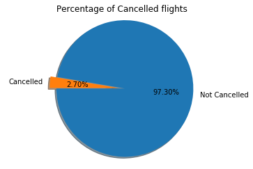

```python
# what is the rate of cancelled flights?
labels = 'Not Cancelled', 'Cancelled'
explode = (0.1, 0)  # explode 1st slice
plt.pie(df.Cancelled.value_counts(), explode=explode, shadow=True, labels=labels, autopct='%.2f%%', startangle=180);
plt.title("Percentage of Cancelled flights", y=0.98, fontsize=12);
plt.axis('equal');
```

### Which cancellation reason is most common?

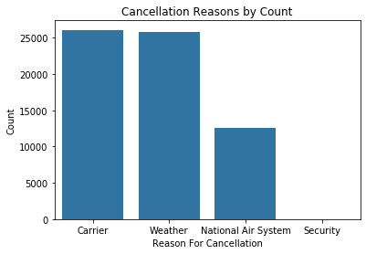

```python
#Getting distribution using Seaborn bar plot

#Define Plot
base_color=sb.color_palette()[0]
g=sb.countplot(data=df,x='CancellationCode',color=base_color,order=['A','B','C','D'])
chart_labels('Reason For Cancellation','Count','Cancellation Reasons by Count')
g.set_xticklabels(['Carrier','Weather','National Air System','Security']);
```

This chart shows that carrier is the most reason for canceling the flights, and security doesn't effect the cancellation that much!

### Which Carrier is the most used by people?

```python
CarrierCounts = df.CarrierDescription.value_counts()
CarrierCounts
```

```
Southwest Airlines Co.          398966
American Airlines Inc.          204519
Skywest Airlines Inc.           195184
American Eagle Airlines Inc.    167860
United Air Lines Inc.           154036
US Airways Inc.                 153539
Delta Air Lines Inc.            151409
Expressjet Airlines Inc.        138757
Northwest Airlines Inc.         122799
Continental Air Lines Inc.      102702
Atlantic Southeast Airlines      92383
Pinnacle Airlines Inc.           88359
AirTran Airways Corporation      86856
Mesa Airlines Inc.               85686
Comair Inc.                      71934
JetBlue Airways                  67478
Alaska Airlines Inc.             49885
Frontier Airlines Inc.           30680
Hawaiian Airlines Inc.           18385
Aloha Airlines Inc.               7800
Name: CarrierDescription, dtype: int64
```

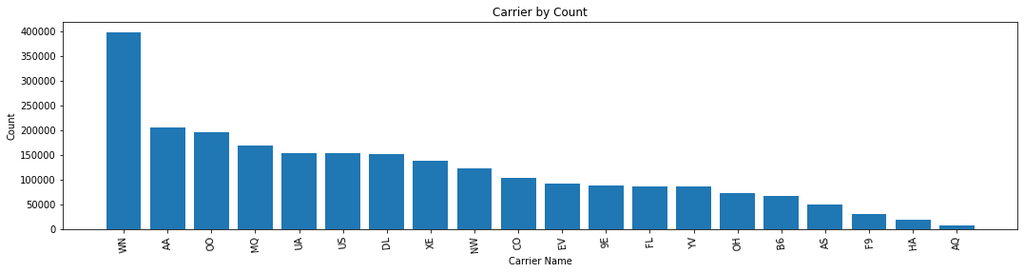

```python
plt.figure(figsize=[18,4])
UniqueCarrier = df.UniqueCarrier.value_counts()
chart_labels('Carrier Name','Count','Carrier by Count')
plt.xticks(rotation=95)
plt.bar(UniqueCarrier.index, UniqueCarrier);
```

This chart shows that WN which is the Southwest Airlines Co. is the most used flights company in us.

## Bivariate Exploration

> In this section, investigate relationships between pairs of variables in your data. Make sure the variables that you cover here have been introduced in some fashion in the previous section (univariate exploration).

### What is the cancellation rate for each carrier?

```python
grouped_carrier_g = df.groupby(by=['CarrierDescription'])
proportional_cancellations_g = grouped_carrier_g['Cancelled'].sum() / grouped_carrier_g.size()
# proportional_cancellations_g
```

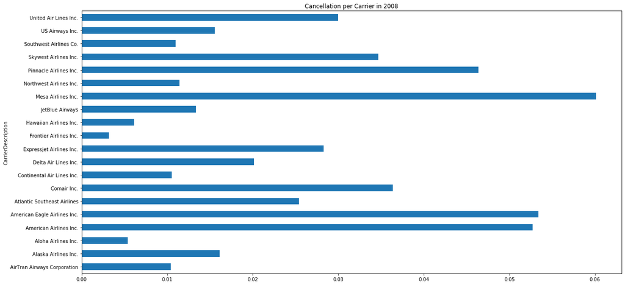

```python
# visualization of cancellation rate per Carrier
proportional_cancellations_g.plot(kind='barh', stacked=False, figsize=[20,10],title ="Cancellation per Carrier in 2008");
```

### What is the relationship among Cannelled, Departure Delay, Arrival Delay in terms of airlines?

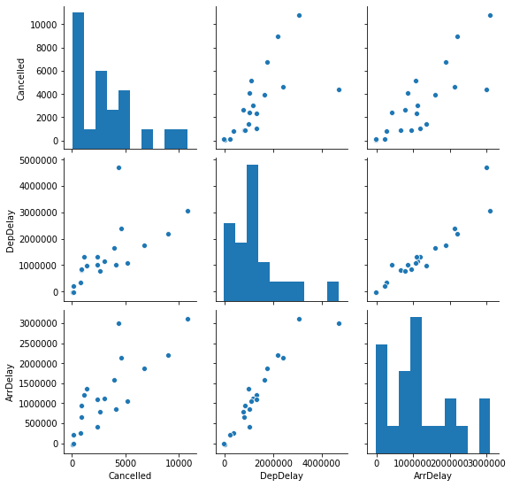

```python
#calculating the relationship among Cannelled, DepDelay, ArrDelay of airlines in terms of airlines.

sample = df.groupby('UniqueCarrier')
sample = pd.merge(
    pd.DataFrame(sample.Cancelled.sum()),
    pd.DataFrame(sample.DepDelay.sum()),
    on='UniqueCarrier'
).merge(
    pd.DataFrame(sample.ArrDelay.sum()), on='UniqueCarrier'
)

sb.pairplot(sample);
```

There are positive correlation coefficients among the Departure and arrival Delay, and also between the delay and the Cancelled flights in terms of airlines.

### Is there is Any relation between Flight Distance and Cancelled Flights?

[figure not shown]

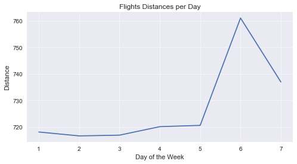

```python
# plot the relation between week days and Cancelled Flights.
plt.figure(figsize=(8,4))
df.groupby('DayOfWeek')['Cancelled'].count().plot()
chart_labels('Day of the Week','Cancellation Counts','Cancellation Counts per Day')
plt.grid(b=True, linewidth=0.5);
plt.style.use('seaborn')

# plot the relation between week days and Flight Distance.
plt.figure(figsize=(8,4))
df.groupby('DayOfWeek')['Distance'].mean().plot()
chart_labels('Day of the Week','Distance','Flights Distances per Day')
plt.grid(b=True, linewidth=0.5);
plt.style.use('seaborn')
```

### Did you observe any interesting relationships between the other features (not the main feature(s) of interest)?

Yes!, when we were discovering the relationship between the cancellation and delay, we define that there is a very strong relationship between the departure and arrival delay.

## Multivariate Exploration

### How many cancellations for each carrier and month?

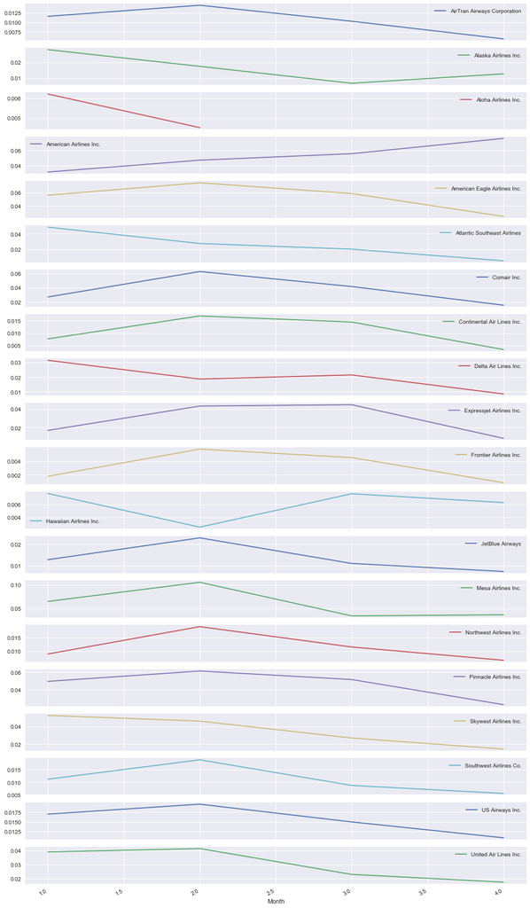

```python
# Cancellations by carrier and month.
grouped_carrier = df.groupby(by=['CarrierDescription', 'Month'])
proportional_cancellations = grouped_carrier['Cancelled'].sum() / grouped_carrier.size()

proportional_cancellations.unstack(0).plot(figsize=(16, 32), subplots=True);
```

in the above chart, we can see the differences between each month cancellations for all the carriers.

### What is the trend of each Carrier from day to day? Which day has the most flight cancellations? Is there a lot of variation in any of these?

```python
df.head(1)
```

|  | Month | DayofMonth | DayOfWeek | DepTime | CRSDepTime | ArrTime | CRSArrTime | UniqueCarrier | FlightNum | TailNum | ... | TaxiOut | Cancelled | CancellationCode | Diverted | CarrierDelay | WeatherDelay | NASDelay | SecurityDelay | LateAircraftDelay | CarrierDescription |
| --- | --- | --- | --- | --- | --- | --- | --- | --- | --- | --- | --- | --- | --- | --- | --- | --- | --- | --- | --- | --- | --- |
| 0 | 1 | 3 | 4 | 1343.0 | 1325 | 1451.0 | 1435 | WN | 588 | N240WN | ... | 9.0 | 0 | 0 | 0 | 16.0 | 0.0 | 0.0 | 0.0 | 0.0 | Southwest Airlines Co. |

1 rows × 29 columns

[figure not shown]

```python
cancelled_df = df.groupby(['DayOfWeek', 'CarrierDescription']).count()['Cancelled']
cancelled_df = cancelled_df.reset_index(name = 'Cancelled')
cancelled_df = cancelled_df.pivot(index = 'CarrierDescription', columns = 'DayOfWeek',
                            values = 'Cancelled')
# figsize in inches
fig, ax = plt.subplots(figsize=(24,10))
sb.heatmap(cancelled_df, annot = True, fmt = '.001f',
           cbar_kws = {'label' : 'count(Cancelled)'}, ax=ax);

chart_labels('Day Of Week','Carrier','Cancelled flights by Day and Carrier')
```

### Resources

- Bureau of Transportation Statistics (BTS), https://www.transtats.bts.gov/Fields.asp?Table_ID=236